# Featurization and Model Tuning Project

#### Context:

Concrete is the most important material in civil engineering. The concrete compressive strength is a highly nonlinear function of age and ingredients. These ingredients include cement, blast furnace slag, fly ash, water, superplasticizer, coarse aggregate, and fine aggregate.

#### Objective:

Modeling of strength of high performance concrete using Machine Learning

## 1. Deliverable -1 (Exploratory data quality report reflecting the following) (20 marks)

### a. Univariate analysis (5 marks)

```python
# Importing the necessary libraries

import numpy as np
import pandas as pd

from matplotlib import pyplot as plt
%matplotlib inline

import seaborn as sns
# sns.set(color_codes=True)


# getting the dataset to jupyter notebook
df = pd.read_csv('concrete.csv')
```

```python
# displaying the top 5 rows of the dataset
df.head()
```

|  | cement | slag | ash | water | superplastic | coarseagg | fineagg | age | strength |
| --- | --- | --- | --- | --- | --- | --- | --- | --- | --- |
| 0 | 141.3 | 212.0 | 0.0 | 203.5 | 0.0 | 971.8 | 748.5 | 28 | 29.89 |
| 1 | 168.9 | 42.2 | 124.3 | 158.3 | 10.8 | 1080.8 | 796.2 | 14 | 23.51 |
| 2 | 250.0 | 0.0 | 95.7 | 187.4 | 5.5 | 956.9 | 861.2 | 28 | 29.22 |
| 3 | 266.0 | 114.0 | 0.0 | 228.0 | 0.0 | 932.0 | 670.0 | 28 | 45.85 |
| 4 | 154.8 | 183.4 | 0.0 | 193.3 | 9.1 | 1047.4 | 696.7 | 28 | 18.29 |

- It shows that there are eight independent variables ( cement, slag, ash, water, superplastic, coarseagg, fineagg, age) and one dependent variable (strength).
- All are numeric

#### *Description of all the variables in the dataset*

Note : As we do not have the domain knowledge, hence done some research on this topic and tried to understand the concepts and then written as per my knowledge.

-------All the ingredients are measured in kg in m3 mixture and strength is measured in MPa-------

##### -> cement :

Cement is actually an ingredient of concrete.It is a water-based binder used to bind other building materials together. It is used in the production of mortar(paste) and concrete during the construction process.

##### -> slag :

Slag is often used in concrete in combination with cement, it is also used in steel making process but mostly used in construction.

##### -> ash :

Ash acts like a cement and a right receipe of concrete and it improves the strength of concrete. It is also replace of cement.

##### -> water :

Water is the key ingredient, which when mixed with cement, forms a paste that binds the aggregate together. The water causes the hardening of concrete through a process called hydration. The role of water is important because the water to cement ratio is the most critical factor in the production of "perfect" concrete.

##### -> superplasticizer :

It is also known as high range water reducers, are additives used in making high strength concrete. They are the chemical compounds that enables the production of concrete with approx 15% less water content. In other words it allows reduction in water content.

##### -> coarse aggregate :

Generally coarse aggregate is crushed stones blended with finer aggregates (such as sand) to fill in the spaces left between the large pieces and to “lock” the larger pieces together. This reduces the amount of cement paste required and decreases the amount of shrinkage that could occur.

##### -> fine aggregate :

As mentioned in the previous variable 'fine aggregates' includes natural sand, crushed stones, gravel used in construction. Aggregates plays in the properties of both fresh and hardened concrete. The proportions between coarse and fine aggregates will change based on the unique characteristics of each aggregate.

##### -> age :

This variable represents the age of the concrete, is the time elapsed since it was poured in place and left to set. We can say that concrete strength increases over time

##### -> strength :

Last but not the least. It is our dependent/output variable which we want to predict under a given mixture of all above independent variables or we can say 'Ingredients'. It defines the strength of the concrete measured in MPa, it lets inspectors know how much pressure can be applied to the concrete before it cracks or fails.

### Definition of Concrete strength in MPa.

A megapascal (MPa) is a measure of the compressive strength of concrete. It lets inspectors know how much pressure can be applied to the concrete before it cracks or fails. One MPa is equal to one million pascals (Pa); as a pascal is one newton of force per square meter, a megapascal is one million newtons per square meter. The higher the MPa of concrete, the stronger the material will be, and the less likely it is to fail.

```python
# Checking the full information of the dataset
print("The dataframe has {} rows and {} columns".format(df.shape[0],df.shape[1]),'\n\n')

df.info()
```

```
The dataframe has 1030 rows and 9 columns


<class 'pandas.core.frame.DataFrame'>
RangeIndex: 1030 entries, 0 to 1029
Data columns (total 9 columns):
 #   Column        Non-Null Count  Dtype
---  ------        --------------  -----
 0   cement        1030 non-null   float64
 1   slag          1030 non-null   float64
 2   ash           1030 non-null   float64
 3   water         1030 non-null   float64
 4   superplastic  1030 non-null   float64
 5   coarseagg     1030 non-null   float64
 6   fineagg       1030 non-null   float64
 7   age           1030 non-null   int64
 8   strength      1030 non-null   float64
dtypes: float64(8), int64(1)
memory usage: 72.5 KB
```

- info() method gives the details about the number of rows (1030), number of columns (9), data types information i.e. except age which is integer type all other columns are float type. Also,there are no null values in the data.

```python
# Checking of missing values
df.isnull().sum()
```

```
cement          0
slag            0
ash             0
water           0
superplastic    0
coarseagg       0
fineagg         0
age             0
strength        0
dtype: int64
```

- No missing values in the dataset but we have zeros in some columns, technically it can be possible as concrete can be created without those as well

```python
df.duplicated().sum() # duplicate rows check
```

```
25
```

```python
df.drop_duplicates(inplace=True) # dropping duplicates. We can drop or retain the duplicates that is not cause anything in model building
df.shape
```

```
(1005, 9)
```

```python
df.describe().T
```

|  | count | mean | std | min | 25% | 50% | 75% | max |
| --- | --- | --- | --- | --- | --- | --- | --- | --- |
| cement | 1005.0 | 278.631343 | 104.344261 | 102.00 | 190.70 | 265.0 | 349.00 | 540.0 |
| slag | 1005.0 | 72.043483 | 86.170807 | 0.00 | 0.00 | 20.0 | 142.50 | 359.4 |
| ash | 1005.0 | 55.536318 | 64.207969 | 0.00 | 0.00 | 0.0 | 118.30 | 200.1 |
| water | 1005.0 | 182.075323 | 21.339334 | 121.80 | 166.60 | 185.7 | 192.90 | 247.0 |
| superplastic | 1005.0 | 6.033234 | 5.919967 | 0.00 | 0.00 | 6.1 | 10.00 | 32.2 |
| coarseagg | 1005.0 | 974.376816 | 77.579667 | 801.00 | 932.00 | 968.0 | 1031.00 | 1145.0 |
| fineagg | 1005.0 | 772.688259 | 80.340435 | 594.00 | 724.30 | 780.0 | 822.20 | 992.6 |
| age | 1005.0 | 45.856716 | 63.734692 | 1.00 | 7.00 | 28.0 | 56.00 | 365.0 |
| strength | 1005.0 | 35.250378 | 16.284815 | 2.33 | 23.52 | 33.8 | 44.87 | 82.6 |

- There are 1005 rows in all the columns now.
- Minimum strength of the concrete is 2.33 indicates poor quality concrete and max is 82.6 which indicates high quality concrete
- Minimum age is 1 day and maximum is 365 days or 1 year and average is ~46 which tells how much reliable the concrete is. And also we can observe that it is highly skewed to the right where the mean is much higher than median, indicates outliers in the dataset
- We can oberve that 'cement' column is approx normally distributed across all the quartiles which tells there are no outliers in the 'cement' variable
- We can see that there are columns that have a minimum value of zero (0). On some columns, a value of zero does not make sense and indicates an invalid or missing value.
- We can see that slag,ash,age are right skewed

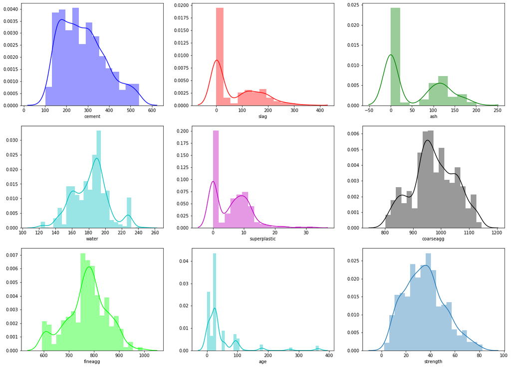

```python
import itertools

k=1
plt.figure(figsize=(20,20))
colors=["b","r","g","c","m","k","lime","c"]
# using for loop to iterate over all the columns in the dataframe and plot the histogram of those

for col,cs in itertools.zip_longest(df.columns[0:],colors): # iterating columns from 0 to 9
    plt.subplot(4,3,k)
    sns.distplot(df[col],color=cs)
    k=k+1
```

### We can see observe the following by above histograms :

- cement is almost normal.
- slag column has three gausssians and rightly skewed.
- ash column has two gaussians and rightly skewed.
- water column has three guassians and slighly left skewed.
- superplastic column has two gaussians and rightly skewed.
- coarseagg column has three guassians and almost normal.
- fineagg column has almost two guassians and looks like normal.
- age column has multiple guassians and highly skewed to the right.

## b. Multivariate analysis (5 marks)

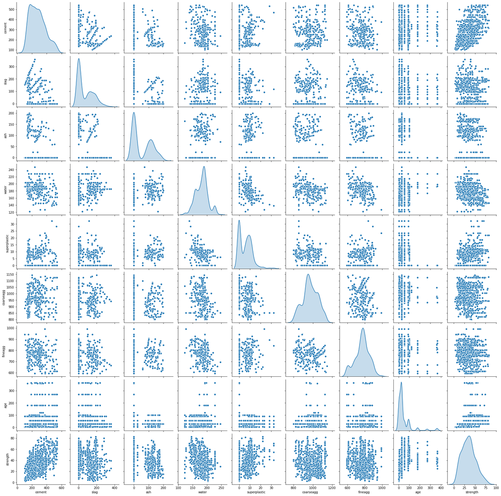

```python
sns.pairplot(df, diag_kind = 'kde')
```

### Diagonal elements:

- It gives the same info which we seen in above distplots.
- cement is almost normal.
- slag column has three gausssians and rightly skewed.
- ash and superplastic columns are having two gaussians and rightly skewed. Shows the presence of outliers
- water column has three guassians and slighly left skewed.Shows the presence of outliers
- coarseagg column has three guassians and almost normal.
- fineagg column has almost two guassians and looks like normal.
- age has multiple guassians and rightly skewed. It shows the presence of outlies.
- strength is almost normal curve #### ------------------------------------------------------------------------------------------------------------------------------------------------------------------------------------------

### Relationship between independent and target column:

- Cement has some positive relationship with strength as we can see that for a given value of cement we have a multiple values of strength. Hence though it has a positive relationship but its not a good predictor for strength of the concrete.
- For a given value of age we have multiple value of strength, hence it is also a weak predictor
- Strength vs other independent columns : Other attributes does not give any strong relationship with strength. Hence, we can see that none of the independent attributes are a good predictors of the strength attribute. There is a no linear relationship between them.
- We cannot use a linear model here as it violates the assumptions of linear model instead we will implement other regressin models

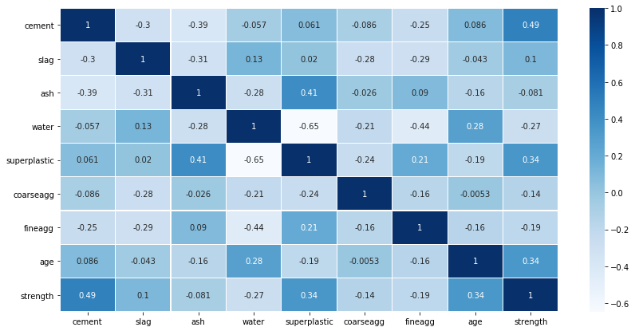

```python
fig= plt.subplots(figsize=(14, 7))
sns.heatmap(df.corr(),annot=True, linewidth = 0.2,cmap="Blues")
```

- Correlation heatmap also shows the same information we observed in pairplot
- Water shows the significant negative linear relationship with superplastic and fineagg columns and some kind of positive with age and slag
- Strength has some positive relationship with cement (0.49) as cement is most important ingredient used to make concrete
- Also, Age and Super Plasticizer are the other two factors influencing Compressive strength
- Many independent columns has almost zero correlation with one another
- ash is a very weak predictor of strength as it has very low correlation with target column, we can remove or retain the varliable

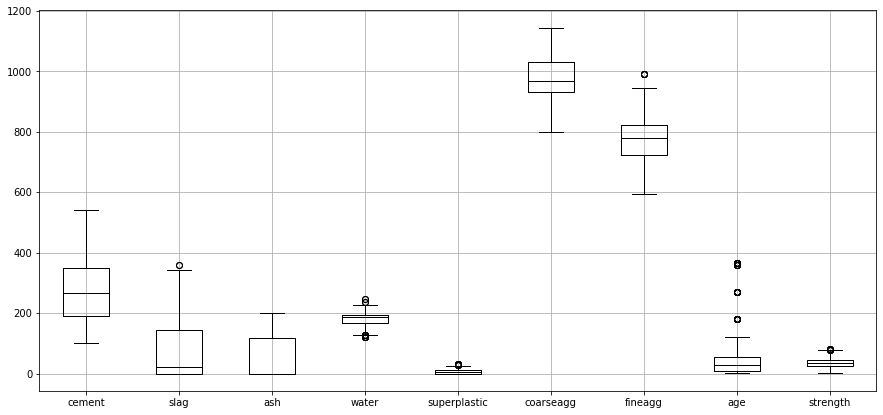

```python
# Boxplot for all the variables
df.boxplot(figsize=(15,7),color='black')
```

## c. Pick one strategy to address the presence outliers and missing values and perform necessary imputation (10 marks)

```python
# Missing values check
df.isnull().sum()
```

```
cement          0
slag            0
ash             0
water           0
superplastic    0
coarseagg       0
fineagg         0
age             0
strength        0
dtype: int64
```

- There are no missing values in the dataset as we have seen already

Outliers Detection

- First of all What are Outliers : Outliers are the datapoints in the dataset that are distant from all other observations. Data points that lies outside the distribution of the dataset. Outliers are also called as anomalies
- Outliers causes significant impact for our statistical analysis, for mean and standard deviation

```python
for col_name in df.columns[:-1]:
    q1 = df[col_name].quantile(0.25)
    q3 = df[col_name].quantile(0.75)
    iqr = q3 - q1

    low = q1-1.5*iqr
    high = q3+1.5*iqr

    # Showing the outliers in every column
    print('Number of outliers in',col_name,'is :', df[(df[col_name] < low) | (df[col_name] > high)][col_name].count())

#   zscore method to find an outlier
#   df1.loc[(df1[col_name] < -3) | (df1[col_name] > 3), col_name] = df1[col_name].median()
#   print('Number of outliers in',col_name,'is :', df1[(df1[col_name] < -3) | (df1[col_name] > 3)][col_name].count())
```

```
Number of outliers in cement is : 0
Number of outliers in slag is : 2
Number of outliers in ash is : 0
Number of outliers in water is : 15
Number of outliers in superplastic is : 10
Number of outliers in coarseagg is : 0
Number of outliers in fineagg is : 5
Number of outliers in age is : 59
```

```python
for col_name in df.columns[:-1]:
    q1 = df[col_name].quantile(0.25)
    q3 = df[col_name].quantile(0.75)
    iqr = q3 - q1

    low = q1-1.5*iqr
    high = q3+1.5*iqr

    # replacing the outliers with median of respective column
    df.loc[(df[col_name] < low) | (df[col_name] > high), col_name] = df[col_name].median()

    # Checking after treating the outliers
    print('Number of outliers in',col_name,'is :', df[(df[col_name] < low) | (df[col_name] > high)][col_name].count())
```

```
Number of outliers in cement is : 0
Number of outliers in slag is : 0
Number of outliers in ash is : 0
Number of outliers in water is : 0
Number of outliers in superplastic is : 0
Number of outliers in coarseagg is : 0
Number of outliers in fineagg is : 0
Number of outliers in age is : 0
```

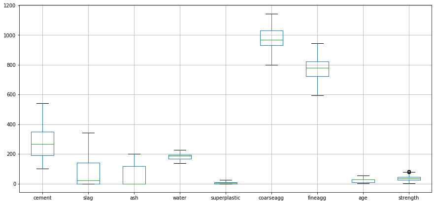

```python
# Boxplot to check outliers and distribution
df.boxplot(figsize=(15,7))
```

- Outliers have been treated

# 2. Deliverable -2 (Feature Engineering techniques) (15 marks)

### a. Identify opportunities (if any) to create a composite feature, drop a feature etc. (5 marks)

```python
df.head(10)
```

|  | cement | slag | ash | water | superplastic | coarseagg | fineagg | age | strength |
| --- | --- | --- | --- | --- | --- | --- | --- | --- | --- |
| 0 | 141.3 | 212.0 | 0.0 | 203.5 | 0.0 | 971.8 | 748.5 | 28.0 | 29.89 |
| 1 | 168.9 | 42.2 | 124.3 | 158.3 | 10.8 | 1080.8 | 796.2 | 14.0 | 23.51 |
| 2 | 250.0 | 0.0 | 95.7 | 187.4 | 5.5 | 956.9 | 861.2 | 28.0 | 29.22 |
| 3 | 266.0 | 114.0 | 0.0 | 228.0 | 0.0 | 932.0 | 670.0 | 28.0 | 45.85 |
| 4 | 154.8 | 183.4 | 0.0 | 193.3 | 9.1 | 1047.4 | 696.7 | 28.0 | 18.29 |
| 5 | 255.0 | 0.0 | 0.0 | 192.0 | 0.0 | 889.8 | 945.0 | 28.0 | 21.86 |
| 6 | 166.8 | 250.2 | 0.0 | 203.5 | 0.0 | 975.6 | 692.6 | 7.0 | 15.75 |
| 7 | 251.4 | 0.0 | 118.3 | 188.5 | 6.4 | 1028.4 | 757.7 | 56.0 | 36.64 |
| 8 | 296.0 | 0.0 | 0.0 | 192.0 | 0.0 | 1085.0 | 765.0 | 28.0 | 21.65 |
| 9 | 155.0 | 184.0 | 143.0 | 194.0 | 9.0 | 880.0 | 699.0 | 28.0 | 28.99 |

### b. Decide on complexity of the model, should it be simple linear model in terms of parameters or would a quadratic or higher degree help (5 marks)

- In machine learning, model complexity often refers to the number of features or terms included in a given predictive model, as well as whether the chosen model is linear, nonlinear, and so on.
- There are some linear models/methods which can control model complexity as well as helps to prevent over fitting
- As there are not too many variables in the dataset, we can say model will not suffer much with complexity. If there are too many variables, leads to overfitting. Some of them are able to help with feature and model selection as well.
- We have to take care of both over fitting and under fitting when building the predictive modelling. Should balance between both bias and variance
- High bias leads to underfit and high variance leads to overfit. In both cases, the model will not make very accurate predictions on new data
- The two most popular regularization methods in the linear regression are ridge regression and lasso. Both methods involve adding a tuning parameter (lambda) to the model, which is designed to impose a penalty on each term's coefficient based on its size, or effect on the model. They penalize large magnitude coefficients when it is set to a high number, coefficients are suppressed significantly, so we can choose the variables according to thier coefficients.
- There are various regression models in supervised learning technique and will try to implement those and observe the accuracies.

### c. Explore for gaussians. If data is likely to be a mix of gaussians, explore individual clusters and present your findings in terms of the independent attributes and their suitability to predict strength (5 marks)

```python
# Scaling all the variables
from scipy.stats import zscore

df_scaled=df.iloc[:,0:]
df_scaled=df.apply(zscore)
```

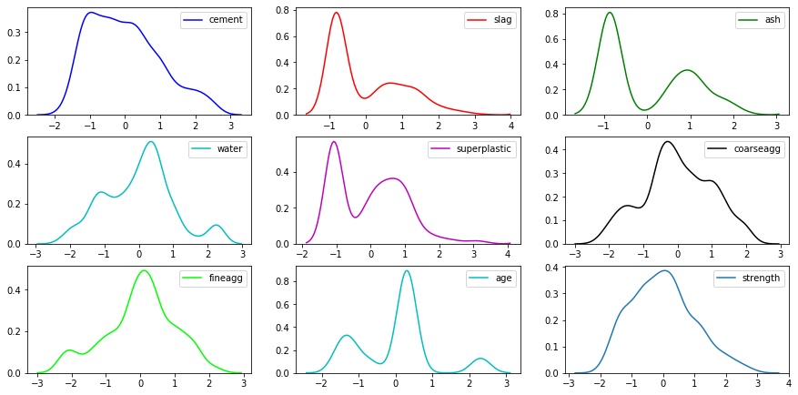

```python
import itertools

k=1
plt.figure(figsize=(15,10))
colors=["b","r","g","c","m","k","lime","c"]
# using for loop to iterate over all the columns in the dataframe and plot the kde of those

for col,cs in itertools.zip_longest(df_scaled.columns[0:],colors): # iterating columns from 0 to 9
    plt.subplot(4,3,k)
    sns.kdeplot(df_scaled[col],color=cs)
    k=k+1
```

- By observing above kdeplots we can say Data is totally mix up of guassians where all the columns are having two or more number of hidden clusters in it
- cement is almost normal but there are more than two groups it has
- slag, water, coarseagg columns has three or more gausssians.
- ash and superplastic columns are having two gaussians
- fineagg column has almost two guassians and looks like normal.
- age has multiple guassians and rightly skewed.
- strength is almost normal curve but has small amount of gaussians hidden inside the distribution.
- Now we will implement kmeans to see how many clusters this dataset has and try to interpret the hidden patterns

```python
from sklearn.cluster import KMeans
```

```python
# Variables are now scaled. Let us now try to create clusters

cluster_range = range(1,15)
cluster_errors = []
for num_clusters in cluster_range:
    clusters = KMeans(num_clusters, n_init = 5)
    clusters.fit(df_scaled)
    cluster_errors.append(clusters.inertia_)

clusters_df = pd.DataFrame({"num_clusters": cluster_range, "cluster_errors": cluster_errors})
clusters_df
```

|  | num_clusters | cluster_errors |
| --- | --- | --- |
| 0 | 1 | 9045.000000 |
| 1 | 2 | 7309.396329 |
| 2 | 3 | 6268.455854 |
| 3 | 4 | 5503.967688 |
| 4 | 5 | 5030.080209 |
| 5 | 6 | 4570.963416 |
| 6 | 7 | 4208.786503 |
| 7 | 8 | 3939.189850 |
| 8 | 9 | 3775.435320 |
| 9 | 10 | 3577.342428 |
| 10 | 11 | 3469.510839 |
| 11 | 12 | 3287.339553 |
| 12 | 13 | 3162.547427 |
| 13 | 14 | 3058.895126 |

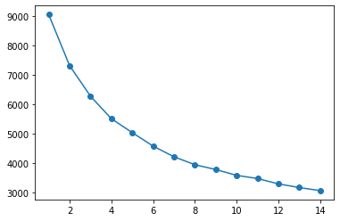

```python
plt.plot( clusters_df.num_clusters, clusters_df.cluster_errors, marker = "o" )
```

- We could not see any bend here, so let's take 6 randomly

```python
kmeans = KMeans(n_clusters=6, n_init = 5, random_state=12345)
kmeans.fit(df_scaled)
pred = kmeans.predict(df_scaled)
```

```python
# Checking the number of datapoints in each cluster

labels = kmeans.labels_
counts = np.bincount(labels[labels>=0])
print(counts)
```

```
[272 169 177 128 171  88]
```

- Distribution of the points in clusters looks skewed.

```python
# adding a new column 'group' which holds the cluster id of each data point
df_scaled['group'] = pred
df_scaled.head()
```

|  | cement | slag | ash | water | superplastic | coarseagg | fineagg | age | strength | group |
| --- | --- | --- | --- | --- | --- | --- | --- | --- | --- | --- |
| 0 | -1.316792 | 1.650657 | -0.865375 | 1.044518 | -1.073915 | -0.033232 | -0.293599 | 0.305628 | -0.329328 | 4 |
| 1 | -1.052152 | -0.342358 | 1.071486 | -1.212290 | 0.928056 | 1.372475 | 0.311864 | -0.694183 | -0.721299 | 0 |
| 2 | -0.274530 | -0.837677 | 0.625836 | 0.240655 | -0.054393 | -0.225388 | 1.136918 | 0.305628 | -0.370491 | 0 |
| 3 | -0.121115 | 0.500389 | -0.865375 | 2.267787 | -1.073915 | -0.546508 | -1.290012 | 0.305628 | 0.651214 | 5 |
| 4 | -1.187348 | 1.314966 | -0.865375 | 0.535238 | 0.612931 | 0.941736 | -0.951105 | 0.305628 | -1.042003 | 4 |

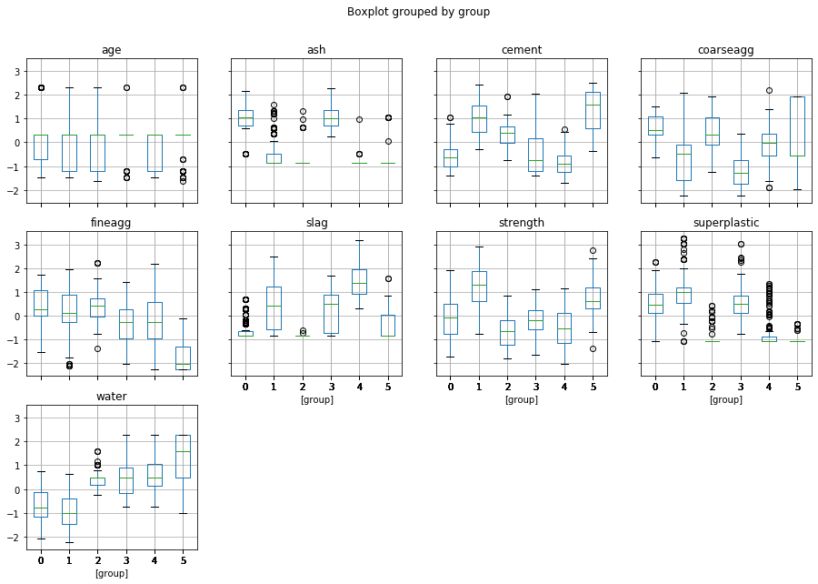

```python
# Instead of printing the neumerical values of the centroids, let us do a visual analysis using box plot group wise

df_scaled.boxplot(by = 'group',  layout=(3,4), figsize=(15, 10));
```

## 3. Deliverable -3 (create the model ) ( 15 marks)

### a. Obtain feature importance for the individual features and present your findings

- Here we are going to create some two or more models to test the accuracy on test data of independent variables and to check which all are the variables are significant

```python
x = df.drop('strength',1)
y = df['strength']

from sklearn.model_selection import train_test_split

x_train, x_test, y_train, y_test = train_test_split(x, y, test_size = 0.2, random_state = 2)
x_train.shape, x_test.shape, y_train.shape, y_test.shape
```

```
((804, 8), (201, 8), (804,), (201,))
```

```python
# The features can be rescaled to have a mean of zero and a standard deviation of 1
# i.e. all the features fall into the same range.

from sklearn.preprocessing import StandardScaler

x = df.iloc[:,:-1] # Features
y = df.iloc[:,-1] # Target
x_train, x_test, y_train, y_test = train_test_split(x, y, test_size=0.3, random_state=2)
sc = StandardScaler()
x_train = sc.fit_transform(x_train)
x_test = sc.transform(x_test)
```

- We will start with Linear Regression since this is the go-to algorithm for any regression problem. The algorithm tries to form a linear relationship between the input features and the target variable i.e. it fits a straight line
- Magnitude od the Coefficients of Linear Regression can be controlled by other regularisationn terms by using lasso and ridge regression.
- Both these variations help in reducing the model complexity and therefore reducing the chances of overfitting on the data.

```python
from sklearn.linear_model import LinearRegression, Lasso, Ridge

# Linear Regression
lr_model = LinearRegression()

# Lasso Regression
lasso_model = Lasso()

# Ridge Regression
ridge_model = Ridge()

# Fitting all the three models on training data
lr_model.fit(x_train, y_train)

lasso_model.fit(x_train, y_train)

ridge_model.fit(x_train, y_train)
```

```
Ridge(alpha=1.0, copy_X=True, fit_intercept=True, max_iter=None,
      normalize=False, random_state=None, solver='auto', tol=0.001)
```

```python
print('Linear Regression')
print('Training set accuracy:\t {:.2f}%'.format(lr_model.score(x_train,y_train)*100))
print('Test set accuracy:\t {:.2f}%'.format(lr_model.score(x_test,y_test)*100))

print('\nLasso Regression')
print('Training set accuracy:\t {:.2f}%'.format(lasso_model.score(x_train,y_train)*100))
print('Test set accuracy:\t {:.2f}%'.format(lasso_model.score(x_test,y_test)*100))

print('\nRidge Regression')
print('Training set accuracy:\t {:.2f}%'.format( ridge_model.score(x_train,y_train)*100))
print('Test set accuracy:\t {:.2f}%'.format(ridge_model.score(x_test,y_test)*100))
```

```
Linear Regression
Training set accuracy:	 70.95%
Test set accuracy:	 70.73%

Lasso Regression
Training set accuracy:	 67.93%
Test set accuracy:	 67.55%

Ridge Regression
Training set accuracy:	 70.95%
Test set accuracy:	 70.73%
```

```python
print ("Lasso model:", (lasso_model.coef_))
```

```
Lasso model: [ 8.06807947  3.02617062  0.         -2.56031181  1.30045065 -0.
 -0.1894831   7.584301  ]
```

- Observe, two coefficients have become 0 in lasso regression indicating drop of those dimensions from the model but the accuracy is lesser compared to ridge and LR

```python
from sklearn.metrics import mean_squared_error, r2_score

y_pred_lr = lr_model.predict(x_test)
y_pred_lasso = lasso_model.predict(x_test)
y_pred_ridge = ridge_model.predict(x_test)

print("Model\t\t\t RMSE \t\t R2")
print("""LinearRegression \t {:.2f} \t\t{:.2f}""".format(  np.sqrt(mean_squared_error(y_test, y_pred_lr)),
                                                         r2_score(y_test, y_pred_lr)))
print("""LassoRegression \t {:.2f} \t\t{:.2f}""".format( np.sqrt(mean_squared_error(y_test, y_pred_lasso)),
                                                        r2_score(y_test, y_pred_lasso)))
print("""RidgeRegression \t {:.2f} \t\t{:.2f}""".format( np.sqrt(mean_squared_error(y_test, y_pred_ridge)),
                                                        r2_score(y_test, y_pred_ridge)))
```

```
Model			 RMSE 		 R2
LinearRegression 	 9.21 		0.71
LassoRegression 	 9.70 		0.68
RidgeRegression 	 9.21 		0.71
```

- There is not much difference between the performance with these three algorithms but the models are very poor in terms of accuracies

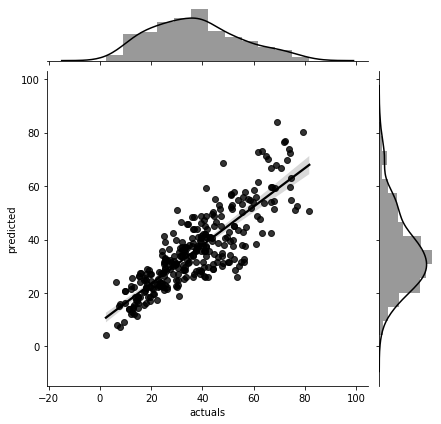

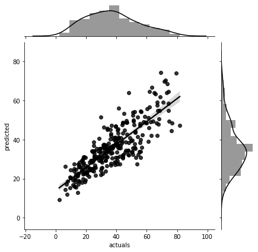

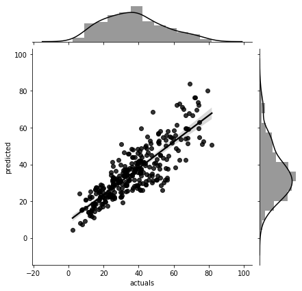

```python
models = [y_pred_lr, y_pred_lasso, y_pred_ridge]

for i in models:
    sns.jointplot(x = y_test, y = i, kind = 'reg', color='black');
    plt.xlabel('actuals')
    plt.ylabel('predicted')
```

- If the predicted values and the target values are equal, then the points on the scatter plot will lie on the straight line. As we can see here, none of the model predicts the Compressive Strength correctly as the data points are more spread out around the line

We will implement Decision Tree Algorithm which represents the data with a tree-like structure, where each node represents a decision taken on a feature. We can expect this algorith would give better performance as there are lot of zeros in some independent columns in the dataset this would help the decision trees build trees based on some conditions on features which can further improve performance.

It also gives us the which are all the important input feaures in the dataset to be selected for the algorithm

```python
from sklearn.tree import DecisionTreeRegressor

dt_model = DecisionTreeRegressor()
dt_model.fit(x_train, y_train)
```

```
DecisionTreeRegressor(ccp_alpha=0.0, criterion='mse', max_depth=None,
                      max_features=None, max_leaf_nodes=None,
                      min_impurity_decrease=0.0, min_impurity_split=None,
                      min_samples_leaf=1, min_samples_split=2,
                      min_weight_fraction_leaf=0.0, presort='deprecated',
                      random_state=None, splitter='best')
```

```python
print('Decision Tree')
print('Training set accuracy:\t {:.2f}%'.format( dt_model.score(x_train,y_train)*100))
print('Test set accuracy:\t {:.2f}%'.format(dt_model.score(x_test,y_test)*100))
```

```
Decision Tree
Training set accuracy:	 97.94%
Test set accuracy:	 72.69%
```

```python
y_pred_dt = dt_model.predict(x_test)
print("Model\t\t\t\t RMSE \t\t R2")
print("""Decision Tree Regressor \t {:.2f} \t\t{:.2f}""".format( np.sqrt(mean_squared_error(y_test, y_pred_dt)),
                                                                r2_score(y_test, y_pred_dt)))
```

```
Model				 RMSE 		 R2
Decision Tree Regressor 	 8.90 		0.73
```

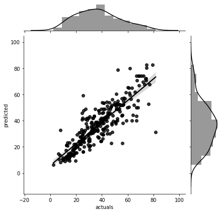

```python
sns.jointplot(y_test, y_pred_dt, kind='reg', color='black')
plt.ylabel('predicted')
plt.xlabel('actuals')
```

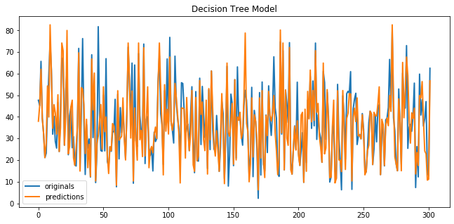

```python
plt.figure(figsize=(11,5))

ax=y_test.reset_index()['strength'].plot(label='originals',linewidth=2);
ax=pd.DataFrame(y_pred_dt)[0].plot(label = 'predictions',linewidth=2)
plt.legend()
plt.title('Decision Tree Model')
```

```python
#printing the feature importance
print('Feature importances:')
imp = pd.DataFrame(columns=['Features','Imp'])
imp['Features'] = x.columns
imp['Imp'] = dt_model.feature_importances_
imp
```

```
Feature importances:
```

|  | Features | Imp |
| --- | --- | --- |
| 0 | cement | 0.362268 |
| 1 | slag | 0.068666 |
| 2 | ash | 0.017399 |
| 3 | water | 0.115477 |
| 4 | superplastic | 0.057612 |
| 5 | coarseagg | 0.044337 |
| 6 | fineagg | 0.030897 |
| 7 | age | 0.303344 |

- The above dataframe shows how much percentage that each feature is important
- So, cement, age and water are significant attributes.
- Here, ash, coarseagg, fineagg, superplastic and slag are the less significant variable.These will impact less to the strength column. This we have seen in pairplot also.

## 4. Deliverable -4 (Tuning the model) (20 marks)

### a. Algorithms that you think will be suitable for this project (5 marks)

Using a Decision Tree Regressor has improved our performance, we can further improve the performance by ensembling more trees. Random Forest Regressor trains randomly initialized trees with random subsets of data sampled from the training data, this will make our model more robust.

```python
from sklearn.ensemble import RandomForestRegressor

rf_model = RandomForestRegressor()
rf_model.fit(x_train, y_train)
```

```
RandomForestRegressor(bootstrap=True, ccp_alpha=0.0, criterion='mse',
                      max_depth=None, max_features='auto', max_leaf_nodes=None,
                      max_samples=None, min_impurity_decrease=0.0,
                      min_impurity_split=None, min_samples_leaf=1,
                      min_samples_split=2, min_weight_fraction_leaf=0.0,
                      n_estimators=100, n_jobs=None, oob_score=False,
                      random_state=None, verbose=0, warm_start=False)
```

```python
print('Random Forest Regressor')
print('Training set accuracy:\t {:.2f}%'.format( rf_model.score(x_train,y_train)*100))
print('Test set accuracy:\t {:.2f}%'.format(rf_model.score(x_test,y_test)*100))
```

```
Random Forest Regressor
Training set accuracy:	 96.46%
Test set accuracy:	 85.91%
```

- This model is also overfits the data as we can see there is much difference between training and test set accuaracy

```python
y_pred_rf = rf_model.predict(x_test)
print("Model\t\t\t\t RMSE \t\t R2")
print("""Random Forest Regressor \t {:.2f} \t\t{:.2f}""".format( np.sqrt(mean_squared_error(y_test, y_pred_rf)),
                                                                r2_score(y_test, y_pred_rf)))
```

```
Model				 RMSE 		 R2
Random Forest Regressor 	 6.39 		0.86
```

- The RMSE has further reduced by ensembling multiple trees.

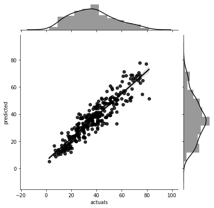

```python
sns.jointplot(y_test, y_pred_rf, kind='reg', color='black');
plt.ylabel('predicted')
plt.xlabel('actuals')
```

- Here we can observe all the points are very much closer to the line, hence the accuracy is high compared to all other above models
- As the models are overfitting we can employ the techniques called CrossValidation and GridSearchCV to regularise the tree based models by pruning or tuning the hyper parameters

Fine tuning machine learning predictive model is a crucial step to improve accuracy of the forecasted results.We will use GridSearchCV to find out the best hyperparameters. Hyperparameters are parameters of the models that can be input as arguments to the models.

Parameter Tuning Using GridDSearch

Using grid search to obtain combination of hyperparameter values of a model that can give us better accuracy. Grid Search evaluates all possible combinations of the parameter values.

```python
# GridSearchCV to find optimal parameters for models, it uses cross validation by making the splits in data

param_grid_rf = {
    'bootstrap': [True],
 'max_depth': list(range(1,8)),
 'max_features': ['auto', 'sqrt'],
 'min_samples_leaf': list(range(1,10)),
 'n_estimators': list(range(100,500,500))
}
```

```python
from sklearn.model_selection import GridSearchCV
gs = GridSearchCV(rf_model,param_grid_rf,cv=5, verbose = 2, n_jobs= 4)
gs.fit(x,y);
```

```
Fitting 5 folds for each of 126 candidates, totalling 630 fits
```

```
[Parallel(n_jobs=4)]: Using backend LokyBackend with 4 concurrent workers.
[Parallel(n_jobs=4)]: Done  33 tasks      | elapsed:    8.0s
[Parallel(n_jobs=4)]: Done 154 tasks      | elapsed:   24.2s
[Parallel(n_jobs=4)]: Done 357 tasks      | elapsed:   54.7s
[Parallel(n_jobs=4)]: Done 630 out of 630 | elapsed:  1.7min finished
```

```python
# printing the optimal accuracy score and hyperparameters
print('We can get accuracy of',gs.best_score_,'using',gs.best_params_)
```

```
We can get accuracy of 0.8404440911494098 using {'bootstrap': True, 'max_depth': 7, 'max_features': 'auto', 'min_samples_leaf': 1, 'n_estimators': 100}
```

```python
# Using those best parameters to create model
rf_tuned = RandomForestRegressor(bootstrap=True,
                             min_samples_leaf=1,
                             max_depth=7,
                             max_features='auto',
                             n_estimators=100,
                             random_state=56)
rf_tuned.fit(x_train,y_train)
```

```
RandomForestRegressor(bootstrap=True, ccp_alpha=0.0, criterion='mse',
                      max_depth=7, max_features='auto', max_leaf_nodes=None,
                      max_samples=None, min_impurity_decrease=0.0,
                      min_impurity_split=None, min_samples_leaf=1,
                      min_samples_split=2, min_weight_fraction_leaf=0.0,
                      n_estimators=100, n_jobs=None, oob_score=False,
                      random_state=56, verbose=0, warm_start=False)
```

```python
print('Random Forest Regressor(Tuned)')
print('Training set accuracy:\t {:.2f}%'.format( rf_tuned.score(x_train,y_train)*100))
print('Test set accuracy:\t {:.2f}%'.format(rf_tuned.score(x_test,y_test)*100))
```

```
Random Forest Regressor(Tuned)
Training set accuracy:	 92.23%
Test set accuracy:	 84.56%
```

### b. Techniques employed to squeeze that extra performance out of the model without making it overfit or underfit (5 marks)

#### So here random forest regressor performs best with an accuracy score of above 85%

### c. Model performance range at 95% confidence level (10 marks)

```python
# Function to perform cross validation and to display the cross validation mean accuracies across several run

from sklearn.model_selection import cross_val_score

scores =[]
def model(algo, x, y):  # defining a function
    cross_val = cross_val_score(algo,x,y,cv=20) # 20 splits
    print ('************************')
    scores.append(cross_val)
    print ("cv-mean :",cross_val.mean())  # printing the average of all the 20 scores
    print ("cv-std  :",cross_val.std())   # printing the standard deviation to check the spread among all the scores
```

```python
print('Decision Tree cv score')
model(dt_model,x, y)

print('\n')

print('Random Forest CV score')
model(rf_model,x, y)
```

```
Decision Tree cv score
cv-mean : 0.8014447110795851
cv-std  : 0.07532188244695806


Random Forest CV score
cv-mean : 0.8593645388994734
cv-std  : 0.05540552310245212
```

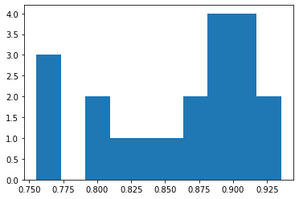

```
95% confidence interval 74.9% and 97.0%
```

```python
# plot scores
plt.hist(scores[1])
plt.show()
# confidence intervals
alpha = 95       # for 95% confidence level
lower =  scores[1].mean()-(scores[1].std()*2) # minus two standard deviation
upper = scores[1].mean()+(scores[1].std()*2)  # plus two standard deviation
print('{}% confidence interval {:.1f}% and {:.1f}%'.format(alpha,lower*100,upper*100))
```

```python
# All the models scores we implemented

data = {
          'Technique' : ['Linear Regression', 'Lasso','Ridge', 'Decision tree',
                       'Random forest', 'DT CV','RF CV','Tuned RF CV'],
          'Score' : [(lr_model.score(x_test,y_test)*100), (lasso_model.score(x_test,y_test)*100),
                     (ridge_model.score(x_test,y_test)*100), (dt_model.score(x_test,y_test)*100),
                     (rf_model.score(x_test,y_test)*100), scores[0].mean()*100, scores[1].mean()*100,
                     (rf_tuned.score(x_test,y_test)*100)]
       }

result = pd.DataFrame(data)
result
```

|  | Technique | Score |
| --- | --- | --- |
| 0 | Linear Regression | 70.734944 |
| 1 | Lasso | 67.547132 |
| 2 | Ridge | 70.732584 |
| 3 | Decision tree | 72.689892 |
| 4 | Random forest | 85.912287 |
| 5 | DT CV | 80.144471 |
| 6 | RF CV | 85.936454 |
| 7 | Tuned RF CV | 84.558867 |

## Conclusion

By above dataframe we can see that Random Forest using cross validation gives us good mean accuracy so that we can give a range estimate in terms of our model performance in the real world As we mentioned in the earlier ensemble of the models performs better with this kind of dataset